# PRECISE open trial: analysis code

Preliminary Effects of PRECISE, a Personalized and Idiographically-Tailored Adjunctive Intervention, on Suicidal Ideation and Psychiatric Symptoms in Young Adults

Kevin S. Kuehn, PhD

Rendered October 10, 2026

This document contains the analysis code for the manuscript. All results are computed from the item-level, de-identified datasets in `data/`: scale scoring, descriptive tables, the Bayesian multilevel models, the responder analysis, and the EMA compliance, missingness and safety summaries.

| Manuscript element | Data file |
| --- | --- |
| Table 1 (demographics) | `precise_demographics.csv` |
| Table 2 (acceptability, feasibility, usability) | `precise_implementation.csv` |
| EMA compliance, missingness models, EMA safety counts, Figure S1 (Multimedia Appendix 1) | `precise_ema.csv` |
| Table 4 and Figure 2 (Bayesian multilevel models) | `precise_visits.csv` |
| Table 5 (≥50% responders) | `precise_visits.csv` |

Figures 2 and S1 are drawn by `make_figure2.R` and `make_figureS1.R`, which this document runs; they write publication files (PDF, 600-dpi TIFF, PNG) to `figures/`.

Figure 1 (CONSORT), Table 3 (session attendance), treatment fidelity and the adverse-event log are summarized from study tracking records and are not computed here.

The first knit compiles and samples seven Stan models (roughly 10 minutes); fitted models are cached in `fits/` so later knits take seconds. Delete `fits/` to refit from scratch.

```r
library(dplyr)
library(tidyr)
library(readr)
library(ggplot2)
library(brms)
library(bayestestR)
library(lme4)

options(mc.cores = min(4, parallel::detectCores()))
SEED <- 20260917
dir.create("fits", showWarnings = FALSE)

tp_levels <- c("baseline", "week6", "week12")
tp_labels <- c("Baseline", "6 weeks", "12 weeks")
```

# Data

```r
visits <- read_csv("data/precise_visits.csv", show_col_types = FALSE) %>%
  mutate(timepoint = factor(timepoint, levels = tp_levels))
implementation <- read_csv("data/precise_implementation.csv", show_col_types = FALSE)
demographics   <- read_csv("data/precise_demographics.csv", show_col_types = FALSE)
ema            <- read_csv("data/precise_ema.csv", show_col_types = FALSE)
promis_par     <- read_csv("data/promis_item_parameters.csv", show_col_types = FALSE)

visits %>% count(timepoint, name = "n participants") %>% knitr::kable()
```

| timepoint | n participants |
| --- | --- |
| baseline | 30 |
| week6 | 28 |
| week12 | 26 |

# Scale scoring

```r
# Sum score requiring a minimum proportion of answered items; missing items are
# replaced by the person's mean of answered items (prorated sum).
prorated_sum <- function(items, min_prop = 0.8) {
  n_ok <- rowSums(!is.na(items))
  out <- rowMeans(items, na.rm = TRUE) * ncol(items)
  out[n_ok < ceiling(min_prop * ncol(items))] <- NA
  out
}

# Expected a posteriori (EAP) theta under the graded response model with a
# standard normal prior, using fixed (published) item parameters.
#   resp: matrix of responses coded 1..5 (rows = people, columns = items)
#   par:  data frame with one row per item: a, b1..b4
grm_eap <- function(resp, par, nodes = seq(-6, 6, length.out = 241)) {
  stopifnot(ncol(resp) == nrow(par))
  prior <- dnorm(nodes)
  b <- as.matrix(par[, c("b1", "b2", "b3", "b4")])
  apply(resp, 1, function(r) {
    answered <- which(!is.na(r))
    if (!length(answered)) return(NA_real_)
    lik <- prior
    for (j in answered) {
      # cumulative P(X >= k) for k = 1..6, i.e. 1, P*(b1), ..., P*(b4), 0
      p_star <- cbind(1, plogis(par$a[j] * outer(nodes, b[j, ], "-")), 0)
      lik <- lik * (p_star[, r[j]] - p_star[, r[j] + 1])
    }
    sum(nodes * lik) / sum(lik)
  })
}
promis_t <- function(data, bank, min_items) {
  par  <- promis_par %>% filter(.data$bank == .env$bank) %>% arrange(position)
  resp <- as.matrix(data[, par$item_id])
  t <- 50 + 10 * grm_eap(resp, par)
  t[rowSums(!is.na(resp)) < min_items] <- NA   # < 80% of items answered
  t
}
```

```r
item <- function(prefix, k, width = 2) sprintf(paste0(prefix, "_%0", width, "d"), k)

# CERQ: nine 4-item subscales (items k, k+9, k+18, k+27), items scored 1-5
cerq_key <- list(
  self_blame = c(1, 10, 19, 28), acceptance = c(2, 11, 20, 29),
  rumination = c(3, 12, 21, 30), positive_refocusing = c(4, 13, 22, 31),
  refocus_on_planning = c(5, 14, 23, 32), positive_reappraisal = c(6, 15, 24, 33),
  putting_into_perspective = c(7, 16, 25, 34), catastrophizing = c(8, 17, 26, 35),
  other_blame = c(9, 18, 27, 36))
cerq_adaptive <- unlist(cerq_key[c("acceptance", "positive_refocusing", "refocus_on_planning",
                                   "positive_reappraisal", "putting_into_perspective")])
cerq_maladaptive <- unlist(cerq_key[c("self_blame", "rumination", "catastrophizing", "other_blame")])

scores <- visits %>%
  mutate(
    # MSSI: items 5-18 are administered only after a positive screen on items
    # 1-4, so unadministered items contribute 0 to the total (range 0-54).
    # CSES: REDCap response options were coded 1-10, so totals range 26-260.
    mssi = rowSums(across(all_of(item("mssi", 1:18))), na.rm = TRUE),
    cerq_adaptive    = prorated_sum(across(all_of(item("cerq", cerq_adaptive)))),
    cerq_maladaptive = prorated_sum(across(all_of(item("cerq", cerq_maladaptive)))),
    cses             = prorated_sum(across(all_of(item("cses", 1:26)))),
    promis_dep = promis_t(visits, "depression", min_items = 23),
    promis_anx = promis_t(visits, "anxiety",    min_items = 24)
  ) %>%
  select(id, timepoint, cssrs, mssi, cerq_adaptive, cerq_maladaptive, cses, promis_dep, promis_anx)
```

Item-level missingness is minimal, so the 80% completion rules never exclude a visit:

```r
tibble(
  measure = c("MSSI screening items (1-4)", "CERQ", "CSES", "PROMIS Depression", "PROMIS Anxiety"),
  `missing item responses` = c(
    sum(is.na(visits[, item("mssi", 1:4)])), sum(is.na(visits[, item("cerq", 1:36)])),
    sum(is.na(visits[, item("cses", 1:26)])),
    sum(is.na(visits[, grep("^EDDEP", names(visits))])),
    sum(is.na(visits[, grep("^EDANX", names(visits))]))),
  `visits scored` = c(sum(!is.na(scores$mssi)), sum(!is.na(scores$cerq_adaptive)),
                      sum(!is.na(scores$cses)), sum(!is.na(scores$promis_dep)),
                      sum(!is.na(scores$promis_anx)))
) %>% knitr::kable()
```

| measure | missing item responses | visits scored |
| --- | --- | --- |
| MSSI screening items (1-4) | 2 | 84 |
| CERQ | 1 | 84 |
| CSES | 0 | 84 |
| PROMIS Depression | 0 | 84 |
| PROMIS Anxiety | 0 | 84 |

Observed means (SD) by visit:

```r
outcomes <- tribble(
  ~var,               ~label,
  "cssrs",            "CSSRS",
  "mssi",             "MSSI",
  "cerq_adaptive",    "CERQ Adaptive (composite)",
  "cerq_maladaptive", "CERQ Maladaptive (composite)",
  "cses",             "CSES (coping self-efficacy)",
  "promis_dep",       "PROMIS Depression (T-score)",
  "promis_anx",       "PROMIS Anxiety (T-score)")

scores_long <- scores %>%
  pivot_longer(-c(id, timepoint), names_to = "var", values_to = "y") %>%
  mutate(var = factor(var, levels = outcomes$var, labels = outcomes$label))

scores_long %>%
  group_by(Outcome = var, timepoint) %>%
  summarise(n = sum(!is.na(y)),
            `M (SD)` = sprintf("%.2f (%.2f)", mean(y, na.rm = TRUE), sd(y, na.rm = TRUE)),
            .groups = "drop") %>%
  pivot_wider(names_from = timepoint, values_from = c(n, `M (SD)`), names_vary = "slowest") %>%
  knitr::kable()
```

| Outcome | n_baseline | M (SD)_baseline | n_week6 | M (SD)_week6 | n_week12 | M (SD)_week12 |
| --- | --- | --- | --- | --- | --- | --- |
| CSSRS | 30 | 3.23 (0.90) | 28 | 1.68 (1.22) | 26 | 0.92 (1.29) |
| MSSI | 30 | 8.43 (8.95) | 28 | 1.71 (3.34) | 26 | 2.92 (7.51) |
| CERQ Adaptive (composite) | 30 | 56.10 (14.48) | 28 | 58.04 (14.08) | 26 | 56.50 (10.48) |
| CERQ Maladaptive (composite) | 30 | 46.31 (10.98) | 28 | 43.89 (9.97) | 26 | 41.85 (7.92) |
| CSES (coping self-efficacy) | 30 | 119.20 (30.18) | 28 | 137.68 (34.74) | 26 | 149.81 (25.36) |
| PROMIS Depression (T-score) | 30 | 66.12 (6.08) | 28 | 60.24 (5.96) | 26 | 59.04 (6.88) |
| PROMIS Anxiety (T-score) | 30 | 64.08 (7.23) | 28 | 60.27 (7.05) | 26 | 59.94 (7.70) |

# Table 1. Baseline demographic characteristics

`precise_demographics.csv` is not linkable to the outcome files and each column was permuted independently before release, so marginal distributions (all that Table 1 reports) are exact but rows do not describe real individuals.

```r
cont_row <- function(x, label) {
  tibble(Characteristic = label, n = NA_integer_,
         `%` = sprintf("M (SD) = %.2f (%.2f); median (range) = %.1f (%d–%d)",
                       mean(x), sd(x), median(x), min(x), max(x)))
}
cat_rows <- function(x, label) {
  tab <- sort(table(x), decreasing = TRUE)
  bind_rows(tibble(Characteristic = label, n = NA_integer_, `%` = ""),
            tibble(Characteristic = paste0(" ", names(tab)), n = as.integer(tab),
                   `%` = sprintf("%.1f%%", 100 * as.integer(tab) / length(x))))
}
bind_rows(
  cont_row(demographics$age, "Age, years"),
  cat_rows(demographics$sex_at_birth, "Sex assigned at birth"),
  cat_rows(demographics$gender_identity, "Gender identity"),
  cat_rows(demographics$race_ethnicity, "Race/Ethnicity"),
  cat_rows(demographics$hispanic_latino, "Hispanic, Latino, Spanish, or Mexican origin"),
  cont_row(demographics$education_years, "Education, years"),
  cat_rows(demographics$current_student, "Current student"),
  cat_rows(demographics$employment, "Employment status"),
  cat_rows(demographics$relationship, "Relationship status")
) %>% knitr::kable(caption = "Table 1. Baseline demographic characteristics (N = 30).")
```

Table 1. Baseline demographic characteristics (N = 30).

| Characteristic | n | % |
| --- | --- | --- |
| Age, years |  | M (SD) = 20.97 (2.37); median (range) = 21.0 (18–26) |
| Sex assigned at birth |  |  |
| Female | 22 | 73.3% |
| Male | 8 | 26.7% |
| Gender identity |  |  |
| Woman | 21 | 70.0% |
| Man | 5 | 16.7% |
| Non-binary | 4 | 13.3% |
| Race/Ethnicity |  |  |
| Asian | 12 | 40.0% |
| White | 8 | 26.7% |
| More than one race | 5 | 16.7% |
| Middle Eastern or North African | 2 | 6.7% |
| Unknown/decline to respond | 2 | 6.7% |
| Black or African American | 1 | 3.3% |
| Hispanic, Latino, Spanish, or Mexican origin |  |  |
| No | 23 | 76.7% |
| Yes | 7 | 23.3% |
| Education, years |  | M (SD) = 14.53 (2.01); median (range) = 15.0 (9–19) |
| Current student |  |  |
| Yes | 29 | 96.7% |
| No | 1 | 3.3% |
| Employment status |  |  |
| Part-time employed | 11 | 36.7% |
| Other | 7 | 23.3% |
| Unemployed, volunteer work | 6 | 20.0% |
| Unemployed | 4 | 13.3% |
| Full-time employed | 2 | 6.7% |
| Relationship status |  |  |
| Single | 23 | 76.7% |
| Member of an unmarried couple | 6 | 20.0% |
| Divorced or separated | 1 | 3.3% |

# Table 2. Feasibility and acceptability

```r
sus_items <- as.matrix(implementation[, item("sus", 1:10)])
odd <- seq(1, 9, 2); even <- seq(2, 10, 2)
imp <- implementation %>%
  transmute(id,
            AIM = rowSums(across(aim_1:aim_4)),
            IAM = rowSums(across(iam_1:iam_4)),
            FIM = rowSums(across(fim_1:fim_4)),
            SUS = 2.5 * (rowSums(sus_items[, odd] - 1) + rowSums(5 - sus_items[, even])))

fmt_range <- function(x) sprintf("%s (%s–%s)", format(median(x), nsmall = 1),
                                 format(min(x)), format(max(x)))
tibble(
  Measure = c("AIM — Acceptability", "IAM — Appropriateness", "FIM — Feasibility", "SUS — Usability"),
  `Scale range` = c("4–20", "4–20", "4–20", "0–100"),
  N = nrow(imp),
  `Total M (SD)` = sapply(imp[-1], function(x) sprintf("%.2f (%.2f)", mean(x), sd(x))),
  `Item-level M (SD)` = c(sapply(imp[c("AIM", "IAM", "FIM")],
                                 function(x) sprintf("%.2f (%.2f)", mean(x / 4), sd(x / 4))), "—"),
  `Median (range)` = sapply(imp[-1], fmt_range)
) %>% knitr::kable(caption = "Table 2. Feasibility and acceptability of PRECISE at post-treatment.")
```

Table 2. Feasibility and acceptability of PRECISE at post-treatment.

| Measure | Scale range | N | Total M (SD) | Item-level M (SD) | Median (range) |
| --- | --- | --- | --- | --- | --- |
| AIM — Acceptability | 4–20 | 28 | 17.21 (2.85) | 4.30 (0.71) | 18.0 (9–20) |
| IAM — Appropriateness | 4–20 | 28 | 16.86 (2.89) | 4.21 (0.72) | 17.0 (9–20) |
| FIM — Feasibility | 4–20 | 28 | 17.18 (2.57) | 4.29 (0.64) | 17.0 (10–20) |
| SUS — Usability | 0–100 | 28 | 75.00 (17.13) | — | 82.5 (30–97.5) |

```r
n_imp <- nrow(imp)
pct <- function(k, n) sprintf("%d/%d (%.1f%%)", k, n, 100 * k / n)
tibble(
  Statistic = c("Below scale midpoint (12) on AIM, IAM or FIM",
                "Maximum rating (20): AIM", "Maximum rating (20): IAM", "Maximum rating (20): FIM",
                "SUS at or above 68 (above-average usability)",
                "SUS at or above 85 (excellent)",
                "Three lowest SUS scores"),
  Value = c(pct(sum(imp$AIM < 12 | imp$IAM < 12 | imp$FIM < 12), n_imp),
            pct(sum(imp$AIM == 20), n_imp), pct(sum(imp$IAM == 20), n_imp), pct(sum(imp$FIM == 20), n_imp),
            pct(sum(imp$SUS >= 68), n_imp), pct(sum(imp$SUS >= 85), n_imp),
            paste(sort(imp$SUS)[1:3], collapse = ", "))
) %>% knitr::kable()
```

| Statistic | Value |
| --- | --- |
| Below scale midpoint (12) on AIM, IAM or FIM | 1/28 (3.6%) |
| Maximum rating (20): AIM | 9/28 (32.1%) |
| Maximum rating (20): IAM | 9/28 (32.1%) |
| Maximum rating (20): FIM | 8/28 (28.6%) |
| SUS at or above 68 (above-average usability) | 18/28 (64.3%) |
| SUS at or above 85 (excellent) | 12/28 (42.9%) |
| Three lowest SUS scores | 30, 50, 52.5 |

```r
round(cor(imp[-1]), 2) %>% knitr::kable(caption = "Pearson correlations among implementation measures.")
```

Pearson correlations among implementation measures.

|  | AIM | IAM | FIM | SUS |
| --- | --- | --- | --- | --- |
| AIM | 1.00 | 0.85 | 0.74 | 0.37 |
| IAM | 0.85 | 1.00 | 0.70 | 0.35 |
| FIM | 0.74 | 0.70 | 1.00 | 0.39 |
| SUS | 0.37 | 0.35 | 0.39 | 1.00 |

# EMA compliance and missingness

`precise_ema.csv` has one row per scheduled prompt (6,251 prompts across 30 participants; built by `02_prepare_ema.R`). `completed` is 1 when a survey was submitted for that prompt. Study weeks are days 1–7, 8–14, …, 36–42; the one participant with a 43rd EMA day has it counted in week 6.

```r
by_person <- ema %>% group_by(ema_id) %>% summarise(rate = mean(completed), .groups = "drop")
tibble(
  `Scheduled prompts` = nrow(ema),
  `Completed surveys` = sum(ema$completed),
  `Overall compliance` = sprintf("%.1f%%", 100 * mean(ema$completed)),
  `Per-participant M (SD)` = sprintf("%.1f%% (%.1f%%)", 100 * mean(by_person$rate), 100 * sd(by_person$rate)),
  `Per-participant range` = sprintf("%.1f%%–%.1f%%", 100 * min(by_person$rate), 100 * max(by_person$rate))
) %>% knitr::kable()
```

| Scheduled prompts | Completed surveys | Overall compliance | Per-participant M (SD) | Per-participant range |
| --- | --- | --- | --- | --- |
| 6251 | 4043 | 64.7% | 64.8% (21.9%) | 8.1%–97.1% |

Compliance by study week and by prompt of the day (pooled over prompts, as reported in the Results):

```r
ema %>% mutate(week = pmin(6, (study_day - 1) %/% 7 + 1)) %>%
  group_by(`Study week` = week) %>%
  summarise(`Scheduled` = n(), `Completed` = sum(completed),
            `Compliance` = sprintf("%.1f%%", 100 * mean(completed))) %>%
  knitr::kable()
```

| Study week | Scheduled | Completed | Compliance |
| --- | --- | --- | --- |
| 1 | 1029 | 882 | 85.7% |
| 2 | 1038 | 767 | 73.9% |
| 3 | 1046 | 709 | 67.8% |
| 4 | 1050 | 616 | 58.7% |
| 5 | 1049 | 574 | 54.7% |
| 6 | 1039 | 495 | 47.6% |

```r
ema %>% group_by(`Prompt` = ping) %>%
  summarise(`Scheduled` = n(), `Completed` = sum(completed),
            `Compliance` = sprintf("%.1f%%", 100 * mean(completed))) %>%
  knitr::kable()
```

| Prompt | Scheduled | Completed | Compliance |
| --- | --- | --- | --- |
| 1 | 1252 | 724 | 57.8% |
| 2 | 1251 | 818 | 65.4% |
| 3 | 1251 | 836 | 66.8% |
| 4 | 1247 | 841 | 67.4% |
| 5 | 1250 | 824 | 65.9% |

### Figure S1 (Multimedia Appendix 1)

```r
source("make_figureS1.R", local = new.env())
```

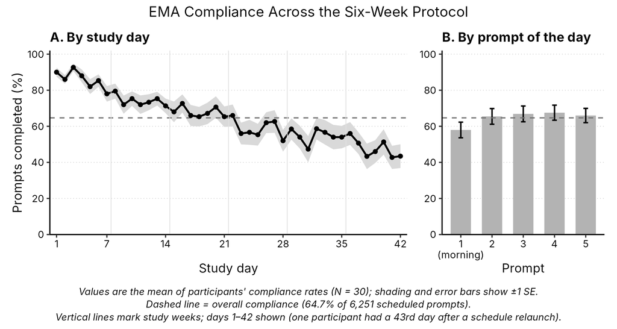

## Predictors of a missed prompt

Frequentist logistic mixed-effects models with a random intercept for participant. Lagged predictors come from the immediately preceding scheduled prompt (within participant) and are therefore only defined when that prompt was completed. Negative emotion is the mean of the five 0–100 items (sad, angry, afraid, ashamed, guilty), standardised.

```r
ema_m <- ema %>%
  mutate(neg_emotion = rowMeans(across(c(anger, shame, sad, fear, guilt)))) %>%
  arrange(ema_id, study_day, ping) %>%
  group_by(ema_id) %>%
  mutate(missed   = 1L - completed,
         prior_na = lag(neg_emotion),
         prior_si = lag(si_any)) %>%
  ungroup() %>%
  mutate(day_wk = (study_day - 1) / 7,                    # per study week
         prior_na_z = as.numeric(scale(prior_na)))

ctrl <- glmerControl(optimizer = "bobyqa")
m_time <- glmer(missed ~ day_wk + ping + (1 | ema_id), data = ema_m, family = binomial, control = ctrl)
m_na   <- glmer(missed ~ day_wk + ping + prior_na_z + (1 | ema_id), data = ema_m, family = binomial, control = ctrl)
m_si   <- glmer(missed ~ day_wk + ping + prior_si + (1 | ema_id), data = ema_m, family = binomial, control = ctrl)

tidy_glmer <- function(m, model) {
  co <- coef(summary(m))
  tibble(Model = model, Term = rownames(co), b = co[, 1], SE = co[, 2],
         OR = exp(co[, 1]),
         `OR 95% CI` = sprintf("[%.2f, %.2f]", exp(co[, 1] - 1.96 * co[, 2]),
                               exp(co[, 1] + 1.96 * co[, 2])),
         p = co[, 4], `n prompts` = nobs(m))
}
bind_rows(tidy_glmer(m_time, "Time only"),
          tidy_glmer(m_na, "+ prior negative emotion"),
          tidy_glmer(m_si, "+ prior suicidal ideation")) %>%
  filter(Term != "(Intercept)") %>%
  mutate(Term = recode(Term, day_wk = "Study week", ping = "Prompt number within day",
                       prior_na_z = "Negative emotion at prior prompt (z)",
                       prior_si = "Suicidal/self-harm thoughts at prior prompt"),
         across(c(b, SE, OR), ~ round(.x, 3)), p = format.pval(p, digits = 2, eps = 0.001)) %>%
  knitr::kable()
```

| Model | Term | b | SE | OR | OR 95% CI | p | n prompts |
| --- | --- | --- | --- | --- | --- | --- | --- |
| Time only | Study week | 0.439 | 0.019 | 1.550 | [1.49, 1.61] | <0.001 | 6251 |
| Time only | Prompt number within day | -0.113 | 0.022 | 0.893 | [0.86, 0.93] | <0.001 | 6251 |
| + prior negative emotion | Study week | 0.290 | 0.026 | 1.336 | [1.27, 1.41] | <0.001 | 3961 |
| + prior negative emotion | Prompt number within day | -0.150 | 0.029 | 0.860 | [0.81, 0.91] | <0.001 | 3961 |
| + prior negative emotion | Negative emotion at prior prompt (z) | 0.073 | 0.071 | 1.076 | [0.94, 1.24] | 0.3 | 3961 |
| + prior suicidal ideation | Study week | 0.291 | 0.025 | 1.338 | [1.27, 1.41] | <0.001 | 4029 |
| + prior suicidal ideation | Prompt number within day | -0.148 | 0.028 | 0.862 | [0.82, 0.91] | <0.001 | 4029 |
| + prior suicidal ideation | Suicidal/self-harm thoughts at prior prompt | -0.547 | 0.148 | 0.579 | [0.43, 0.77] | <0.001 | 4029 |

# EMA safety summary

```r
done <- ema %>% filter(completed == 1)
n_done <- nrow(done)
count_row <- function(label, flag) {
  flag <- coalesce(flag, FALSE)
  tibble(Event = label, Surveys = sum(flag),
         `% of completed surveys` = sprintf("%.1f%%", 100 * sum(flag) / n_done),
         Participants = n_distinct(done$ema_id[flag]))
}
bind_rows(
  count_row("Thoughts of self-harm or suicide (gating item)", done$si_any == 1),
  count_row("Self-harm or suicide attempt in past 30 minutes", done$selfharm_30m == 1),
  count_row("Any suicidal intent in past 30 minutes", done$intent_suicide_30m >= 1),
  count_row("Current intent: none", done$intent_suicide_now == 0),
  count_row("Current intent: a little (brief thoughts, no intent)", done$intent_suicide_now == 1),
  count_row("Current intent: moderate (thoughts, no intent)", done$intent_suicide_now == 2),
  count_row("Current intent: a lot / severe (planning or specific plan)", done$intent_suicide_now >= 3)
) %>% knitr::kable()
```

| Event | Surveys | % of completed surveys | Participants |
| --- | --- | --- | --- |
| Thoughts of self-harm or suicide (gating item) | 665 | 16.4% | 28 |
| Self-harm or suicide attempt in past 30 minutes | 11 | 0.3% | 5 |
| Any suicidal intent in past 30 minutes | 332 | 8.2% | 22 |
| Current intent: none | 93 | 2.3% | 18 |
| Current intent: a little (brief thoughts, no intent) | 87 | 2.2% | 17 |
| Current intent: moderate (thoughts, no intent) | 149 | 3.7% | 9 |
| Current intent: a lot / severe (planning or specific plan) | 3 | 0.1% | 2 |

```r
done %>% filter(intent_suicide_now == 2) %>% count(ema_id, sort = TRUE) %>%
  summarise(`Surveys with moderate current intent` = sum(n),
            `From the single highest-reporting participant` = max(n)) %>%
  knitr::kable()
```

| Surveys with moderate current intent | From the single highest-reporting participant |
| --- | --- |
| 149 | 129 |

# Bayesian multilevel models (Table 4)

Each outcome is modelled as `y ~ timepoint + (1 | id)` with a Gaussian likelihood: time is a categorical fixed effect (baseline as reference) and participants have random intercepts. Weakly informative priors are placed on the two change coefficients and on the between-person SD: Normal(0, 10) and Student-t(3, 0, 5) for every outcome except the CSES, whose 26–260 range calls for Normal(0, 50) and Student-t(3, 0, 20). The intercept and residual SD keep the `brms` defaults. Sampling: 4 chains × 3,000 iterations (1,000 warm-up) = 8,000 posterior draws.

```r
model_spec <- tribble(
  ~var,               ~prior_b,           ~prior_sd,
  "cssrs",            "normal(0, 10)",    "student_t(3, 0, 5)",
  "mssi",             "normal(0, 10)",    "student_t(3, 0, 5)",
  "cerq_adaptive",    "normal(0, 10)",    "student_t(3, 0, 5)",
  "cerq_maladaptive", "normal(0, 10)",    "student_t(3, 0, 5)",
  "cses",             "normal(0, 50)",    "student_t(3, 0, 20)",
  "promis_dep",       "normal(0, 10)",    "student_t(3, 0, 5)",
  "promis_anx",       "normal(0, 10)",    "student_t(3, 0, 5)"
) %>% left_join(outcomes, by = "var")

model_spec %>% select(Outcome = label, `Prior: change coefficients` = prior_b,
                      `Prior: between-person SD` = prior_sd) %>% knitr::kable()
```

| Outcome | Prior: change coefficients | Prior: between-person SD |
| --- | --- | --- |
| CSSRS | normal(0, 10) | student_t(3, 0, 5) |
| MSSI | normal(0, 10) | student_t(3, 0, 5) |
| CERQ Adaptive (composite) | normal(0, 10) | student_t(3, 0, 5) |
| CERQ Maladaptive (composite) | normal(0, 10) | student_t(3, 0, 5) |
| CSES (coping self-efficacy) | normal(0, 50) | student_t(3, 0, 20) |
| PROMIS Depression (T-score) | normal(0, 10) | student_t(3, 0, 5) |
| PROMIS Anxiety (T-score) | normal(0, 10) | student_t(3, 0, 5) |

```r
fit_outcome <- function(var, prior_b, prior_sd) {
  d <- scores %>% select(id, timepoint, y = all_of(var)) %>% filter(!is.na(y))
  brm(y ~ timepoint + (1 | id), data = d, family = gaussian(),
      prior = c(set_prior(prior_b, class = "b"), set_prior(prior_sd, class = "sd")),
      chains = 4, iter = 3000, warmup = 1000, seed = SEED,
      control = list(adapt_delta = 0.95), refresh = 0,
      file = file.path("fits", var), file_refit = "on_change")
}
fits <- Map(fit_outcome, model_spec$var, model_spec$prior_b, model_spec$prior_sd)
```

```r
summarise_fit <- function(fit, label, effect_size = FALSE) {
  draws <- as_draws_df(fit)
  y_sd  <- sd(fit$data$y)
  rhat  <- rhat(fit)
  pooled_sd <- sqrt(draws$sd_id__Intercept^2 + draws$sigma^2)
  one <- function(par, timepoint, change) {
    x <- draws[[par]]
    out <- tibble(Outcome = label, Timepoint = timepoint,
                  Estimate = median(x), lower = quantile(x, .025), upper = quantile(x, .975),
                  pd = NA_real_, rope = NA_real_, Rhat = rhat[[par]], es = NA_character_)
    if (change) {
      out$pd   <- 100 * as.numeric(p_direction(x))
      out$rope <- 100 * as.numeric(rope(x, range = c(-0.1, 0.1) * y_sd, ci = 1))
      if (effect_size) {
        d <- x / pooled_sd
        out$es <- sprintf("%.2f [%.2f, %.2f]", median(d), quantile(d, .025), quantile(d, .975))
      }
    }
    out
  }
  bind_rows(one("b_Intercept", "Intercept (Baseline)", FALSE),
            one("b_timepointweek6", "6-week change", TRUE),
            one("b_timepointweek12", "12-week change", TRUE))
}

table4 <- bind_rows(Map(summarise_fit, fits, model_spec$label, TRUE))

table4 %>%
  transmute(Outcome, Timepoint,
            Estimate = sprintf("%.2f", Estimate),
            `95% CrI` = sprintf("[%.2f, %.2f]", lower, upper),
            # 8,000 draws cannot show a pd of exactly 100%
            pd = ifelse(is.na(pd), "–", ifelse(pd > 99.995, ">99.9%", sprintf("%.2f%%", pd))),
            `% in ROPE` = ifelse(is.na(rope), "–", sprintf("%.2f%%", rope)),
            Rhat = sprintf("%.3f", Rhat),
            `ES [95% CrI]` = coalesce(es, "")) %>%
  knitr::kable(caption = "Table 4. Posterior estimates for change from baseline to 6- and 12-week follow-up. Estimate = posterior median; pd = probability of direction; ROPE = ±0.1 SD of the outcome; ES = change divided by the model-implied pooled SD, sqrt(between-person variance + residual variance).")
```

Table 4. Posterior estimates for change from baseline to 6- and 12-week follow-up. Estimate = posterior median; pd = probability of direction; ROPE = ±0.1 SD of the outcome; ES = change divided by the model-implied pooled SD, sqrt(between-person variance + residual variance).

| Outcome | Timepoint | Estimate | 95% CrI | pd | % in ROPE | Rhat | ES [95% CrI] |
| --- | --- | --- | --- | --- | --- | --- | --- |
| CSSRS | Intercept (Baseline) | 3.23 | [2.80, 3.64] | – | – | 1.001 |  |
| CSSRS | 6-week change | -1.55 | [-2.00, -1.09] | >99.9% | 0.00% | 1.001 | -1.32 [-1.79, -0.87] |
| CSSRS | 12-week change | -2.28 | [-2.75, -1.81] | >99.9% | 0.00% | 1.001 | -1.94 [-2.49, -1.43] |
| MSSI | Intercept (Baseline) | 7.87 | [5.32, 10.32] | – | – | 1.001 |  |
| MSSI | 6-week change | -6.40 | [-9.21, -3.60] | >99.9% | 0.00% | 1.000 | -0.89 [-1.34, -0.49] |
| MSSI | 12-week change | -5.38 | [-8.21, -2.53] | 99.99% | 0.09% | 1.000 | -0.75 [-1.19, -0.35] |
| CERQ Adaptive (composite) | Intercept (Baseline) | 56.14 | [51.60, 60.74] | – | – | 1.000 |  |
| CERQ Adaptive (composite) | 6-week change | 1.46 | [-3.16, 6.22] | 73.42% | 36.01% | 1.001 | 0.11 [-0.24, 0.46] |
| CERQ Adaptive (composite) | 12-week change | 0.97 | [-3.75, 5.63] | 65.53% | 39.19% | 1.000 | 0.07 [-0.28, 0.42] |
| CERQ Maladaptive (composite) | Intercept (Baseline) | 46.22 | [42.65, 49.79] | – | – | 1.001 |  |
| CERQ Maladaptive (composite) | 6-week change | -2.03 | [-5.24, 1.13] | 89.91% | 22.55% | 1.000 | -0.20 [-0.54, 0.11] |
| CERQ Maladaptive (composite) | 12-week change | -3.20 | [-6.42, 0.03] | 97.36% | 8.21% | 1.000 | -0.32 [-0.66, 0.00] |
| CSES (coping self-efficacy) | Intercept (Baseline) | 119.46 | [108.45, 130.33] | – | – | 1.001 |  |
| CSES (coping self-efficacy) | 6-week change | 17.63 | [7.32, 28.54] | 99.92% | 0.45% | 1.000 | 0.56 [0.23, 0.95] |
| CSES (coping self-efficacy) | 12-week change | 29.30 | [18.21, 40.50] | >99.9% | 0.00% | 1.000 | 0.94 [0.56, 1.35] |
| PROMIS Depression (T-score) | Intercept (Baseline) | 66.05 | [63.81, 68.40] | – | – | 1.005 |  |
| PROMIS Depression (T-score) | 6-week change | -5.67 | [-7.70, -3.59] | >99.9% | 0.00% | 1.000 | -0.88 [-1.26, -0.53] |
| PROMIS Depression (T-score) | 12-week change | -6.51 | [-8.60, -4.38] | >99.9% | 0.00% | 1.000 | -1.01 [-1.42, -0.64] |
| PROMIS Anxiety (T-score) | Intercept (Baseline) | 64.06 | [61.46, 66.65] | – | – | 1.004 |  |
| PROMIS Anxiety (T-score) | 6-week change | -3.76 | [-5.82, -1.66] | 99.96% | 0.25% | 1.000 | -0.51 [-0.83, -0.22] |
| PROMIS Anxiety (T-score) | 12-week change | -3.60 | [-5.70, -1.50] | 99.95% | 0.51% | 1.000 | -0.49 [-0.80, -0.19] |

Convergence and sampling diagnostics across all parameters of each model:

```r
bind_rows(lapply(names(fits), function(v) {
  s <- posterior::summarise_draws(as_draws_df(fits[[v]]), "rhat", "ess_bulk", "ess_tail")
  s <- s[!grepl("^(r_id|lp__|lprior)", s$variable), ]
  tibble(Outcome = outcomes$label[outcomes$var == v], `n obs` = nobs(fits[[v]]),
         `max Rhat` = round(max(s$rhat), 3), `min bulk ESS` = round(min(s$ess_bulk)),
         `min tail ESS` = round(min(s$ess_tail)),
         `divergent transitions` = sum(nuts_params(fits[[v]], pars = "divergent__")$Value))
})) %>% knitr::kable()
```

| Outcome | n obs | max Rhat | min bulk ESS | min tail ESS | divergent transitions |
| --- | --- | --- | --- | --- | --- |
| CSSRS | 84 | 1.001 | 2544 | 3394 | 0 |
| MSSI | 84 | 1.001 | 2553 | 3228 | 0 |
| CERQ Adaptive (composite) | 84 | 1.001 | 2692 | 3534 | 0 |
| CERQ Maladaptive (composite) | 84 | 1.002 | 2028 | 2769 | 0 |
| CSES (coping self-efficacy) | 84 | 1.001 | 2455 | 4334 | 0 |
| PROMIS Depression (T-score) | 84 | 1.005 | 2210 | 3773 | 0 |
| PROMIS Anxiety (T-score) | 84 | 1.004 | 1295 | 2620 | 0 |

# Figure 2. Model-estimated trajectories of suicidal ideation

Points are posterior medians of the model-implied mean at each timepoint (intercept + change coefficient, computed draw by draw) and bars are 95% credible intervals from the same draws, so they match Table 4. Grey lines are participants’ observed scores. `make_figure2.R` refits the CSSRS and MSSI models with the specification above and therefore loads them from `fits/`.

```r
source("make_figure2.R", local = new.env())
```

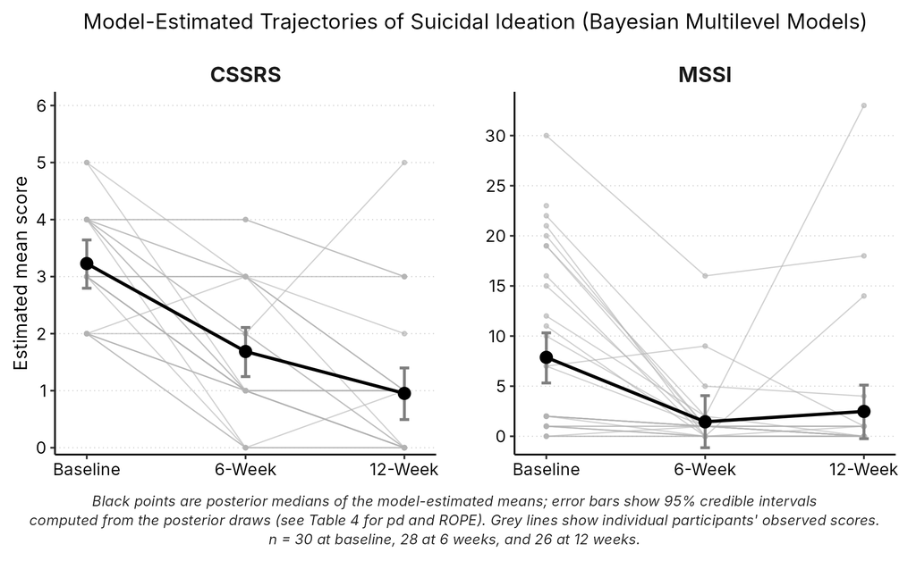

```r
readr::read_csv("figures/figure2_values.csv", show_col_types = FALSE) %>% knitr::kable()
```

| Outcome | Timepoint | n | Mean | 95% CrI lower | 95% CrI upper |
| --- | --- | --- | --- | --- | --- |
| cssrs | Baseline | 30 | 3.23 | 2.80 | 3.64 |
| cssrs | 6-Week | 28 | 1.69 | 1.25 | 2.11 |
| cssrs | 12-Week | 26 | 0.95 | 0.49 | 1.40 |
| mssi | Baseline | 30 | 7.87 | 5.32 | 10.32 |
| mssi | 6-Week | 28 | 1.44 | -1.14 | 4.05 |
| mssi | 12-Week | 26 | 2.48 | -0.24 | 5.10 |

# Table 5. Clinically meaningful response (≥50% reduction from baseline)

A relative reduction is undefined for a baseline score of 0, so those participants are excluded from that measure’s responder analysis.

```r
responders <- scores %>%
  select(id, timepoint, CSSRS = cssrs, MSSI = mssi) %>%
  pivot_longer(c(CSSRS, MSSI), names_to = "Measure", values_to = "y") %>%
  group_by(id, Measure) %>%
  mutate(baseline = y[timepoint == "baseline"]) %>%
  ungroup() %>%
  filter(timepoint != "baseline", !is.na(y), baseline > 0) %>%
  group_by(Measure, timepoint) %>%
  summarise(n = n(), k = sum(y <= 0.5 * baseline), .groups = "drop") %>%
  mutate(responders = sprintf("%d (%.1f%%)", k, 100 * k / n)) %>%
  select(-k) %>%
  pivot_wider(names_from = timepoint, values_from = c(n, responders), names_vary = "slowest")

responders %>%
  rename(`n (6-week)` = n_week6, `≥50% responders, 6-week` = responders_week6,
         `n (12-week)` = n_week12, `≥50% responders, 12-week` = responders_week12) %>%
  knitr::kable(caption = "Table 5. Participants achieving a ≥50% reduction from baseline.")
```

Table 5. Participants achieving a ≥50% reduction from baseline.

| Measure | n (6-week) | ≥50% responders, 6-week | n (12-week) | ≥50% responders, 12-week |
| --- | --- | --- | --- | --- |
| CSSRS | 28 | 18 (64.3%) | 26 | 22 (84.6%) |
| MSSI | 25 | 21 (84.0%) | 24 | 19 (79.2%) |

```r
scores %>% filter(timepoint == "baseline") %>%
  summarise(`Baseline MSSI = 0 (excluded from MSSI responder analysis)` = sum(mssi == 0)) %>%
  knitr::kable()
```

| Baseline MSSI = 0 (excluded from MSSI responder analysis) |
| --- |
| 3 |